# Experiment No 4

[figure not shown]

### Experiment No. 04

[figure not shown]

**AIM**

**Study of Clustering Algorithm in NLP**

**Theory/Procedure/Algorithm**

Clustering is a technique used in unsupervised machine learning to group a set of objects such that objects in the same group (or cluster) are more similar to each other than to those in other groups. In NLP, clustering algorithms are used to group similar documents or text snippets, which can be useful for tasks like topic modeling, document organization, and information retrieval.

**Common Clustering Algorithms**:

1. **K-Means Clustering**:
   - `Theory`: K-Means is a centroid-based clustering algorithm that partitions data into K clusters. It assigns each data point to the nearest centroid and then recalculates centroids based on the mean of the points in each cluster. The process repeats until convergence.
   - `Advantages`: Simple to implement and computationally efficient.
   - `Disadvantages`: Requires specifying the number of clusters (K) beforehand and can be sensitive to outliers.
2. **Hierarchical Clustering**:
   - `Theory`: Hierarchical clustering builds a hierarchy of clusters either through agglomerative (bottom-up) or divisive (top-down) approaches. Agglomerative clustering starts with each data point as a separate cluster and merges the closest pairs, while divisive clustering starts with one cluster and recursively splits it.
   - `Advantages`: Does not require specifying the number of clusters in advance and provides a dendrogram (tree-like diagram) of clusters.
   - `Disadvantages`: Can be computationally expensive for large datasets and may not handle noise well.
3. **DBSCAN (Density-Based Spatial Clustering of Applications with Noise)**:
   - `Theory`: DBSCAN clusters data based on the density of data points. It defines clusters as areas of high density separated by areas of low density. Points that are in low-density regions are considered noise.
   - `Advantages`: Can find arbitrarily shaped clusters and does not require specifying the number of clusters.
   - `Disadvantages`: Sensitive to the choice of parameters and may struggle with varying densities.

##### Dependencies

```python
import numpy as np
import pandas as pd
from sklearn.feature_extraction.text import TfidfVectorizer
from sklearn.cluster import KMeans, DBSCAN
from sklearn.preprocessing import StandardScaler
from scipy.cluster.hierarchy import dendrogram, linkage, fcluster
import matplotlib.pyplot as plt
```

##### Data Preparation: Assume `documents` is a list of text documents.

```python
documents = [
    "Machine learning is a field of artificial intelligence.",
    "Natural language processing involves understanding text.",
    "Deep learning models are used for image recognition.",
    "AI technologies include machine learning and neural networks.",
    "Text classification is a part of NLP.",
    "Neural networks can learn patterns in data.",
]

# Convert documents to TF-IDF matrix
vectorizer = TfidfVectorizer(stop_words='english')
X = vectorizer.fit_transform(documents)
```

```python
# K-Means clustering
kmeans = KMeans(n_clusters=2, random_state=42)
kmeans_labels = kmeans.fit_predict(X)

# Print results
print("K-Means Labels:", kmeans_labels)
```

```
K-Means Labels: [0 0 0 1 0 1]
```

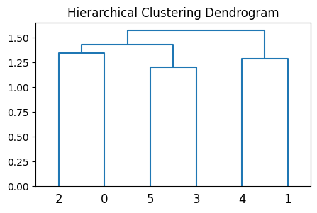

```
Hierarchical Clustering Labels: [2 1 2 2 1 2]
```

```python
# Hierarchical clustering
linked = linkage(X.toarray(), 'ward')
plt.figure(figsize=(5, 3))
dendrogram(linked, orientation='top', distance_sort='descending', show_leaf_counts=True)
plt.title('Hierarchical Clustering Dendrogram')
plt.show()

# Cut the dendrogram to form flat clusters
hierarchical_labels = fcluster(linked, t=2, criterion='maxclust')
print("Hierarchical Clustering Labels:", hierarchical_labels)
```

```python
# Standardize the features
scaler = StandardScaler(with_mean=False)
X_scaled = scaler.fit_transform(X.toarray())

# DBSCAN clustering
dbscan = DBSCAN(eps=0.5, min_samples=2)
dbscan_labels = dbscan.fit_predict(X_scaled)

# Print results
print("DBSCAN Labels:", dbscan_labels)
```

```
DBSCAN Labels: [-1 -1 -1 -1 -1 -1]
```

**CONCLUSION**

Overall, each algorithm has its strengths and weaknesses, and the choice of clustering method depends on the specific characteristics of the dataset and the goals of the analysis.

**ASSESSMENT**

[figure not shown]